# Analysis of Wine Quality by Grace J. Cho

The wine data set contains information on over 6000 red and white variants of the Portuguese “Vinho Verde” wine.

In this analysis, I will explore the relationships between various variables that may have an effect on quality of Red and White variants of Portuguese “Vinho Verde” wine and compare the difference between the 2 wine types. In particular, I am interested in how wine taste (e.g. sweet or bitter) affects its quality. Following are variables of interest to be explored in more detail.

- Alcohol : percent alcohol content of the wine
- Residual sugar: the amount of sugar remaining after fermentation stops, it’s rare to find wines with less than 1 gram/liter and wines with greater than 45 grams/liter are considered sweet.
- Volatile acidity: the amount of acetic acid in wine, which at too high of levels can lead to an unpleasant, vinegar taste.
- pH: describes how acidic or basic a wine is on a scale from 0 (very acidic) to 14 (very basic).

```
## [1] 6497   13
```

```
## 'data.frame':    6497 obs. of  13 variables:
##  $ fixed.acidity       : num  7 6.3 8.1 7.2 7.2 8.1 6.2 7 6.3 8.1 ...
##  $ volatile.acidity    : num  0.27 0.3 0.28 0.23 0.23 0.28 0.32 0.27 0.3 0.22 ...
##  $ citric.acid         : num  0.36 0.34 0.4 0.32 0.32 0.4 0.16 0.36 0.34 0.43 ...
##  $ residual.sugar      : num  20.7 1.6 6.9 8.5 8.5 6.9 7 20.7 1.6 1.5 ...
##  $ chlorides           : num  0.045 0.049 0.05 0.058 0.058 0.05 0.045 0.045 0.049 0.044 ...
##  $ free.sulfur.dioxide : num  45 14 30 47 47 30 30 45 14 28 ...
##  $ total.sulfur.dioxide: num  170 132 97 186 186 97 136 170 132 129 ...
##  $ density             : num  1.001 0.994 0.995 0.996 0.996 ...
##  $ pH                  : num  3 3.3 3.26 3.19 3.19 3.26 3.18 3 3.3 3.22 ...
##  $ sulphates           : num  0.45 0.49 0.44 0.4 0.4 0.44 0.47 0.45 0.49 0.45 ...
##  $ alcohol             : num  8.8 9.5 10.1 9.9 9.9 10.1 9.6 8.8 9.5 11 ...
##  $ quality             : int  6 6 6 6 6 6 6 6 6 6 ...
##  $ wine.color          : Factor w/ 2 levels "Red","White": 2 2 2 2 2 2 2 2 2 2 ...
```

```
##  fixed.acidity    volatile.acidity  citric.acid     residual.sugar
##  Min.   : 3.800   Min.   :0.0800   Min.   :0.0000   Min.   : 0.600
##  1st Qu.: 6.400   1st Qu.:0.2300   1st Qu.:0.2500   1st Qu.: 1.800
##  Median : 7.000   Median :0.2900   Median :0.3100   Median : 3.000
##  Mean   : 7.215   Mean   :0.3397   Mean   :0.3186   Mean   : 5.443
##  3rd Qu.: 7.700   3rd Qu.:0.4000   3rd Qu.:0.3900   3rd Qu.: 8.100
##  Max.   :15.900   Max.   :1.5800   Max.   :1.6600   Max.   :65.800
##    chlorides       free.sulfur.dioxide total.sulfur.dioxide
##  Min.   :0.00900   Min.   :  1.00      Min.   :  6.0
##  1st Qu.:0.03800   1st Qu.: 17.00      1st Qu.: 77.0
##  Median :0.04700   Median : 29.00      Median :118.0
##  Mean   :0.05603   Mean   : 30.53      Mean   :115.7
##  3rd Qu.:0.06500   3rd Qu.: 41.00      3rd Qu.:156.0
##  Max.   :0.61100   Max.   :289.00      Max.   :440.0
##     density             pH          sulphates         alcohol
##  Min.   :0.9871   Min.   :2.720   Min.   :0.2200   Min.   : 8.00
##  1st Qu.:0.9923   1st Qu.:3.110   1st Qu.:0.4300   1st Qu.: 9.50
##  Median :0.9949   Median :3.210   Median :0.5100   Median :10.30
##  Mean   :0.9947   Mean   :3.219   Mean   :0.5313   Mean   :10.49
##  3rd Qu.:0.9970   3rd Qu.:3.320   3rd Qu.:0.6000   3rd Qu.:11.30
##  Max.   :1.0390   Max.   :4.010   Max.   :2.0000   Max.   :14.90
##     quality      wine.color
##  Min.   :3.000   Red  :1599
##  1st Qu.:5.000   White:4898
##  Median :6.000
##  Mean   :5.818
##  3rd Qu.:6.000
##  Max.   :9.000
```

## Univariate Plots Section

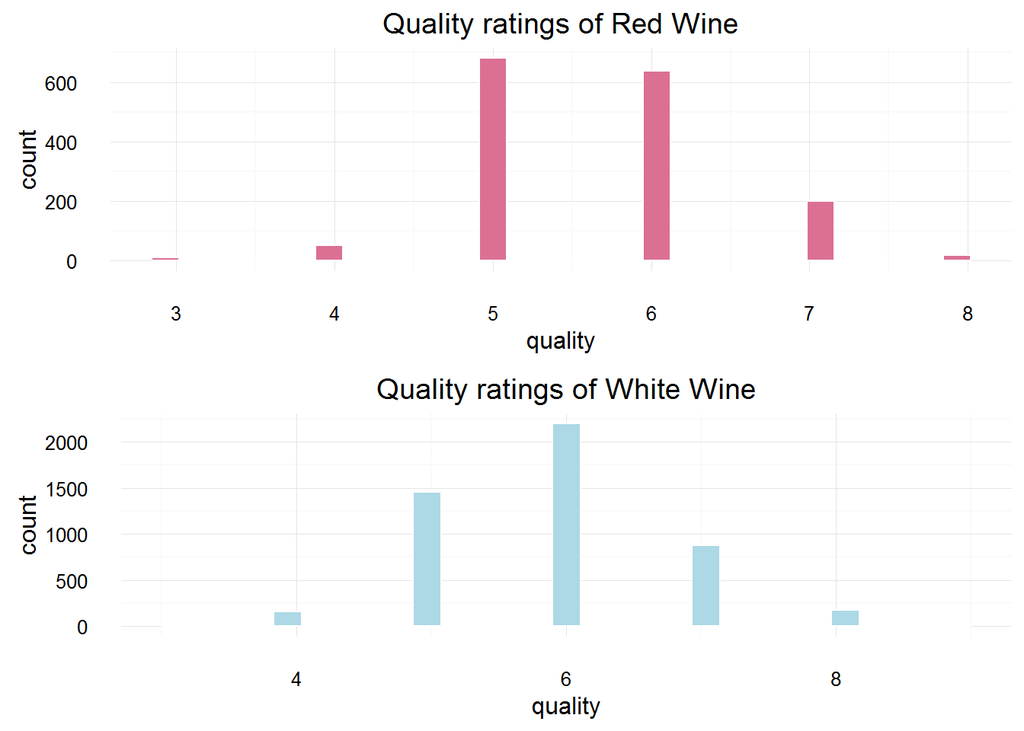

```
##
##            3    4    5    6    7    8    9
##   Red     10   53  681  638  199   18    0
##   White   20  163 1457 2198  880  175    5
```

Quality distributions for both Red and White wine appear to have normal distributions. Difference is that Red wine’s rating peaks approx. at 5 whereas White wine’s rating peaks at 6. In the sample, only White wine received the highest possible ratings of 9. When comparing Red and White wine, we should note their sample size. As White wine has a larger sample than Red wine, we cannot draw insights from sum/count values.

Let’s take a look at the distribution of key variables.

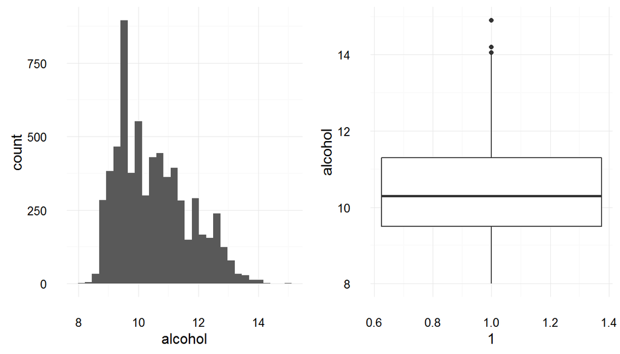

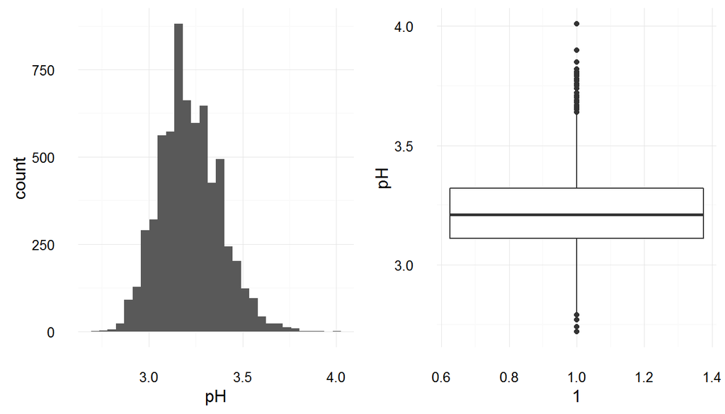

```
##    Min. 1st Qu.  Median    Mean 3rd Qu.    Max.
##    8.00    9.50   10.30   10.49   11.30   14.90
```

```
##    Min. 1st Qu.  Median    Mean 3rd Qu.    Max.
##   2.720   3.110   3.210   3.219   3.320   4.010
```

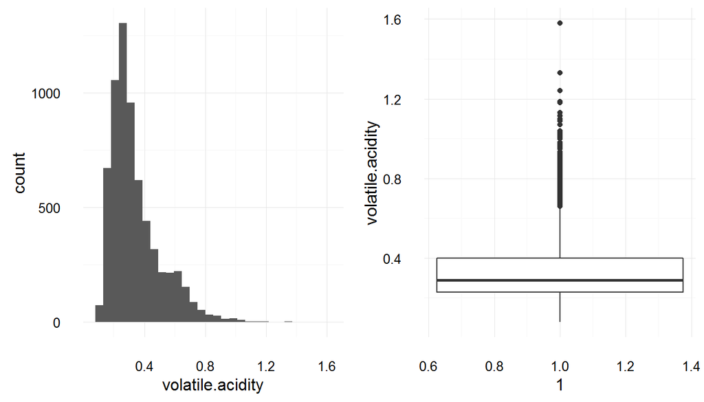

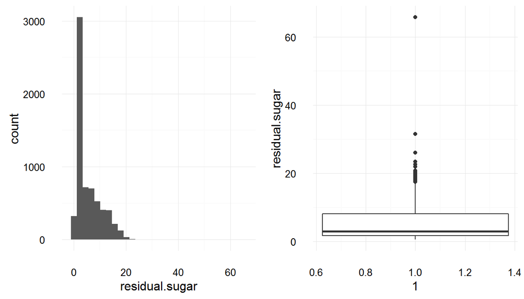

```
##    Min. 1st Qu.  Median    Mean 3rd Qu.    Max.
##  0.0800  0.2300  0.2900  0.3397  0.4000  1.5800
```

```
##    Min. 1st Qu.  Median    Mean 3rd Qu.    Max.
##   0.600   1.800   3.000   5.443   8.100  65.800
```

Volatile.acidity and residual.sugar plots on the other hand appear to be right skewed, with significant number of outliers. Unlike the outliers in alcohol and pH, outliers in volatile.acidity and residual.sugar are far in range from 1st and 3rd quartiles. In residual.sugar boxplot for example, you can see there is one outlier past the 60g / dm^3 level. To take a closer look at the main chunk of data, I will need to adjust the scales and remove the outliers for these right skewed plots.

How do these variables vary by wine type? Using frequency polygons, let’s compare the plots.

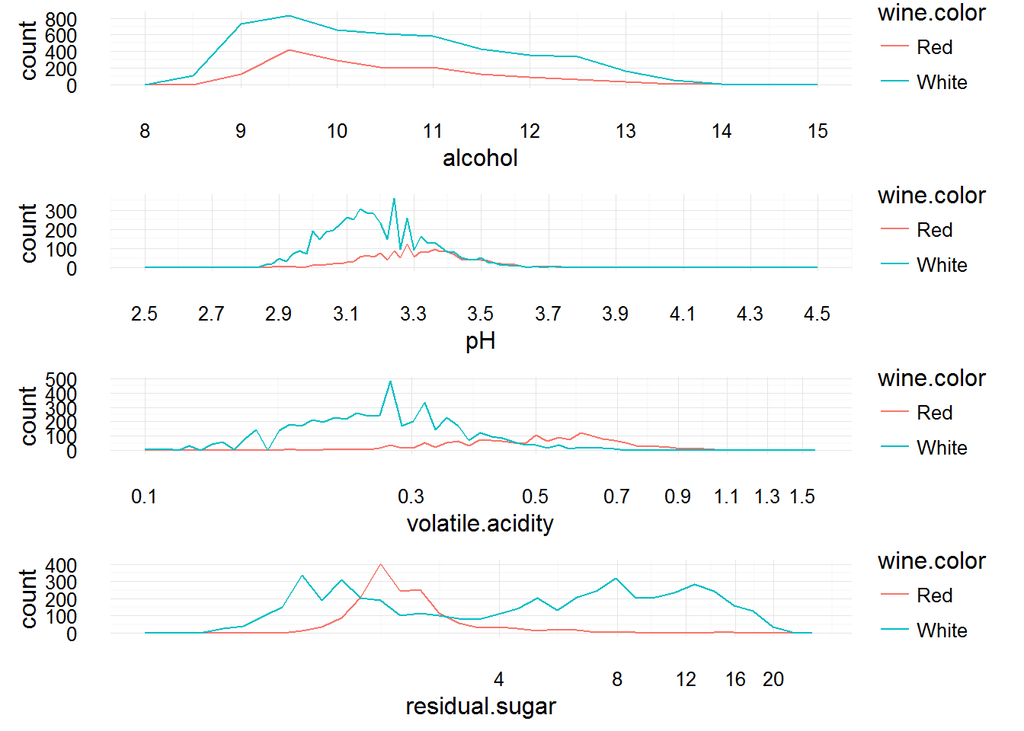

While alcohol and pH distributions for both Red and White wine are similar in shape, we can see that distributions for volatile.acidity and residual.sugar tell a different story.

For volatile.acidity, although there are significantly higher number of White wine samples with volatile.acidity level around 0.2, Red wine samples have higher volatile.acidity level. For residual.sugar, while White wine graph shows a bimodal distribution with higher residual.sugar level, Red wine has a single peak with lower residual.sugar level overall. Next, let’s look at the relationship between these variables and quality ratings.

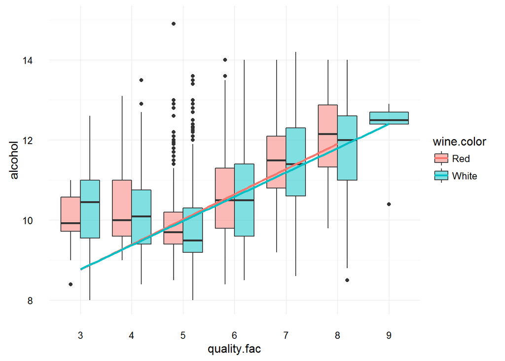

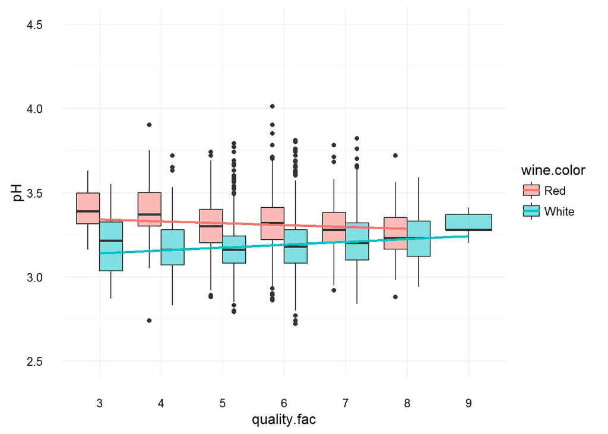

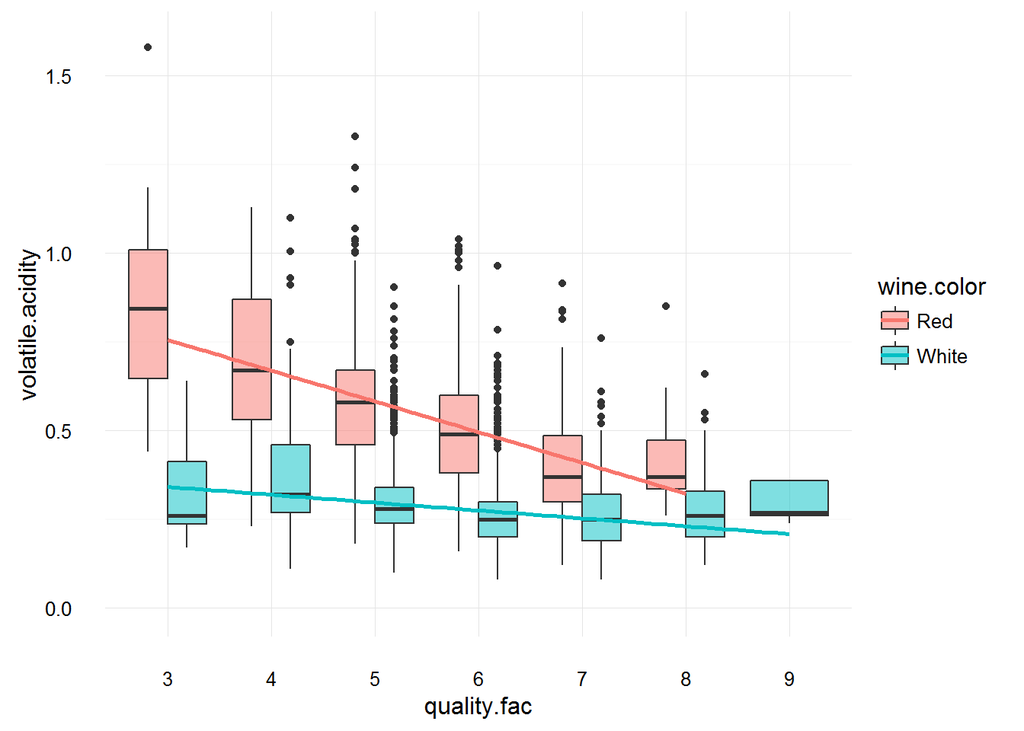

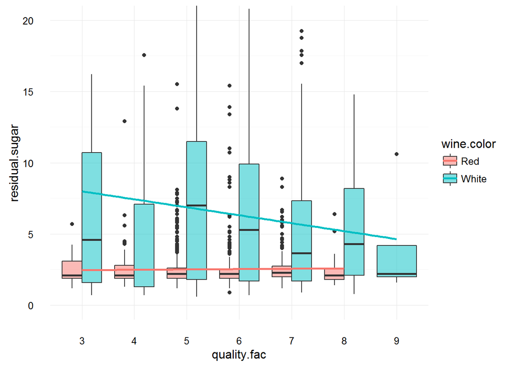

We can observe the following from above box plots:

- Alcohol & Quality: as quality ratings increase, median alcohol level first decreases then gradually increases for both Red and White wine. For quality rating of 5, there are significant number of outliers.
- pH & Quality: as quality ratings increase, median of pH level remains between 3 and 3.5. There are several outliers, especially for quality ratings 5 and 6, but overall pH seems to stay constant across the sample.
- Volatile.acidity & Quality: as quality ratings increase, volatile.acidity level decreases notably for Red wine. Volatile.acidity levels in Red wine seem to have a significant relationship with quality.
- Residual.sugar & Quality: as quality ratings increase, residual.sugar level varies for White wine. Overall, higher quality ratings seem to correlate with lower residual.sugar level. For Red wine, residual.sugar level remain low overall, with some outliers in ratings 5-7 range.

Let’s take a closer look using numerical summaries for residual.sugar and volatile.acidity.

```
## wine$wine.color: Red
##    Min. 1st Qu.  Median    Mean 3rd Qu.    Max.
##  0.1200  0.3900  0.5200  0.5278  0.6400  1.5800
## --------------------------------------------------------
## wine$wine.color: White
##    Min. 1st Qu.  Median    Mean 3rd Qu.    Max.
##  0.0800  0.2100  0.2600  0.2782  0.3200  1.1000
```

```
## wine$wine.color: Red
##    Min. 1st Qu.  Median    Mean 3rd Qu.    Max.
##   0.900   1.900   2.200   2.539   2.600  15.500
## --------------------------------------------------------
## wine$wine.color: White
##    Min. 1st Qu.  Median    Mean 3rd Qu.    Max.
##   0.600   1.700   5.200   6.391   9.900  65.800
```

First summary displays summary stats of volatile.acidity. As expected, the Red wine has higher average volatile.acidity level when compared to White wine.

Second summary displays summary stats of residual.sugar. This time, we can see that White wine has higher median and mean values with a max of 65.8 (over 4 times the max level of Red wine).

## Univariate Analysis

### What is the structure of your dataset?

There are 1599 samples of Red Wine and 4898 samples of White Wine with 13 variables (fixed.acidity, volatile.acidity, citric.acid, residual.sugar, chlorides, free.sulfur.dioxide, total.sulfur.dioxide, density, pH, sulphates, alcohol, quality, wine.color). Wine.color and quality have the following levels.

wine.color: Red, White quality: 3, 4, 5, 6, 7, 8, 9 (with 9 being the best rating)

### What is/are the main feature(s) of interest in your dataset?

To explore how taste affects wine quality, the main focus of analysis will be variables that could change the taste of wine, such as volatile.acidity and residual.sugar. How these variables vary between Red and White wine will also be analyzed.

### What other features in the dataset do you think will help support your investigation into your feature(s) of interest?

As wine taste is often described as finding the right balance, looking at density may help support the investigation.

### Did you create any new variables from existing variables in the dataset?

A factor version of ‘Quality’ variable was created for graphical purposes. Also, alcohol.bucket is created in multivariate section to further explore quality’s correlation with alcohol.

### Of the features you investigated, were there any unusual distributions? Did you perform any operations on the data to tidy, adjust, or change the form of the data? If so, why did you do this?

As many variables are small in number, it was hard to undestand how the data is distributed in the initial graphs. To allow for easier interpretation, I used scale_x_continuous to set the appropriate limits and breaks. For residual.sugar however, the graph was right skewed so I applied scale_xlog10 to transform the scale. Once the scale was transformed, it became much easier to understand the data points.

## Bivariate Plots Section

To understand the overall variables correlations, a scatterplot matrix is created as below.

```
##  [1] "fixed.acidity"        "volatile.acidity"     "citric.acid"
##  [4] "residual.sugar"       "chlorides"            "free.sulfur.dioxide"
##  [7] "total.sulfur.dioxide" "density"              "pH"
## [10] "sulphates"            "alcohol"              "quality"
## [13] "wine.color"           "quality.fac"
```

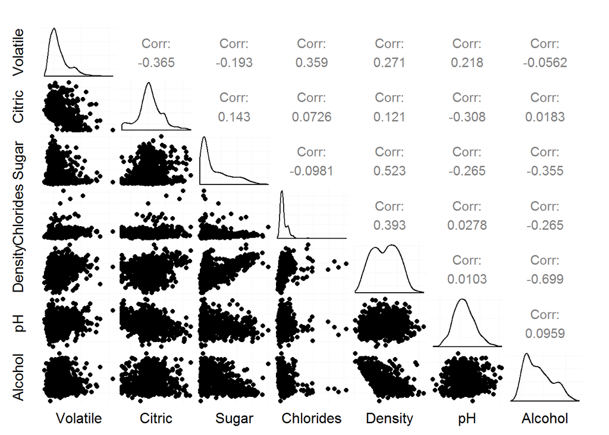

Using the scatterplot matrix, we are able to identify few variables that are more strongly correlated. In this next section, we will look at a few of these examples. A variable that has a surprisingly high correlation with volatile.acidity is citric.acid.

```
##
##  Pearson's product-moment correlation
##
## data:  citric.acid and volatile.acidity
## t = -32.903, df = 6495, p-value < 2.2e-16
## alternative hypothesis: true correlation is not equal to 0
## 95 percent confidence interval:
##  -0.3986341 -0.3569453
## sample estimates:
##        cor
## -0.3779813
```

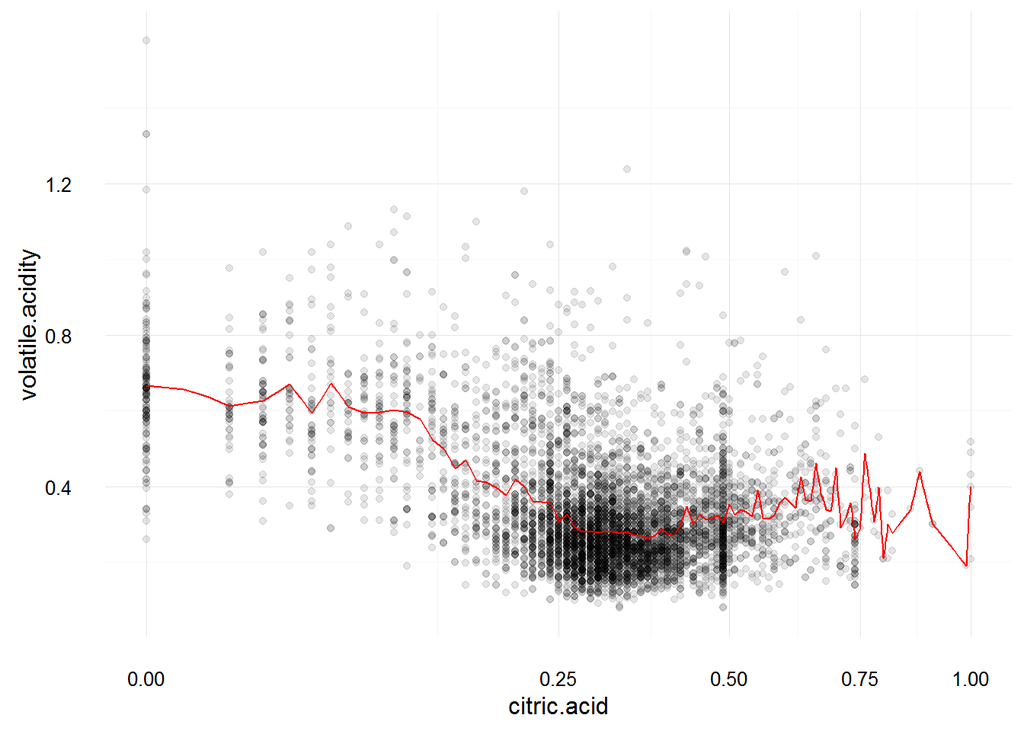

As citric.acid level increases, volatile.acidity level decreases. The mean summary line (shown in red), clearly drops between citric.acid level of 0.1~0.2. The plot does become noisier as citric.acid level approaches 1, but the overall correlation appears to be negative.

On the other hand, a variable pair that has a surprisingly low correlation value is alcohol and pH.

```
##
##  Pearson's product-moment correlation
##
## data:  alcohol and pH
## t = 9.8442, df = 6495, p-value < 2.2e-16
## alternative hypothesis: true correlation is not equal to 0
## 95 percent confidence interval:
##  0.09721831 0.14513734
## sample estimates:
##       cor
## 0.1212485
```

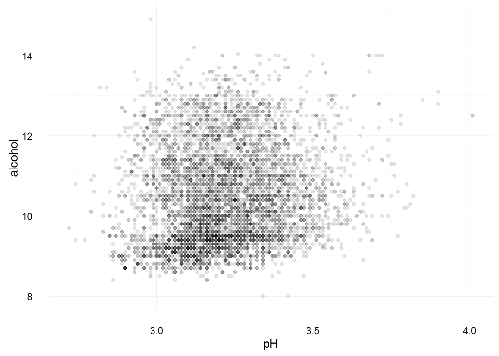

Looking at both the scatterplot and Pearson’s R, we can see there is no clear relationship between alcohol and pH. Alcohol however, seems to be correlated with residual.sugar.

```
##
##  Pearson's product-moment correlation
##
## data:  alcohol and residual.sugar
## t = -31.04, df = 6495, p-value < 2.2e-16
## alternative hypothesis: true correlation is not equal to 0
## 95 percent confidence interval:
##  -0.3804069 -0.3380525
## sample estimates:
##        cor
## -0.3594148
```

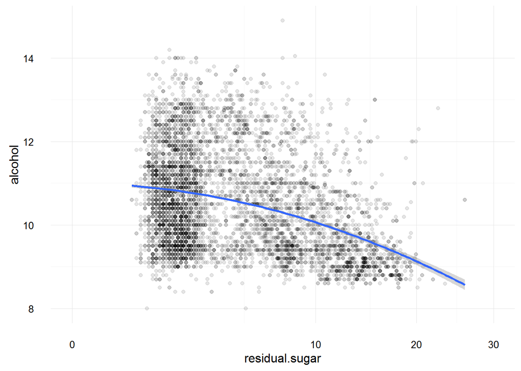

As residual.sugar level increases, alcohol level steadily decreases. This raises the question, how is alcohol and residual.sugar correlated with density?

```
##
##  Pearson's product-moment correlation
##
## data:  residual.sugar and density
## t = 53.423, df = 6495, p-value < 2.2e-16
## alternative hypothesis: true correlation is not equal to 0
## 95 percent confidence interval:
##  0.5353934 0.5691865
## sample estimates:
##      cor
## 0.552517
```

```
##
##  Pearson's product-moment correlation
##
## data:  alcohol and density
## t = -76.14, df = 6495, p-value < 2.2e-16
## alternative hypothesis: true correlation is not equal to 0
## 95 percent confidence interval:
##  -0.6993829 -0.6736787
## sample estimates:
##        cor
## -0.6867454
```

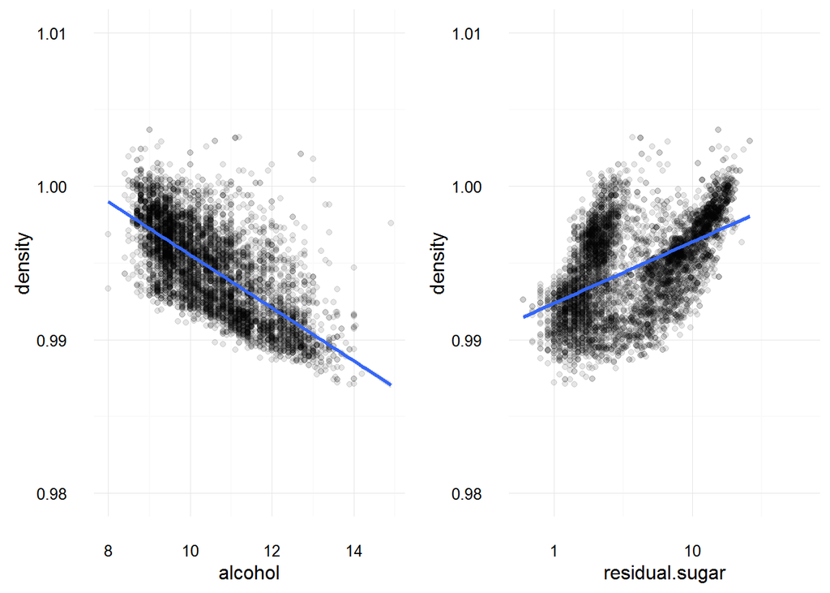

Density appears to have a strong correlation with alcohol and residual.sugar. While density decreases as alcohol level increases, it increases as residual.sugar level increases. Looking at geom_smooth lines, we can clearly see the opposite effects alcohol and residual.sugar have on density. Note here that because density and these variables have a strong correlation, we would not use them together when building regression models.

Another interesting variable pair is citric.acid and chlorides.

```
##
##  Pearson's product-moment correlation
##
## data:  chlorides and citric.acid
## t = 3.1453, df = 6495, p-value = 0.001667
## alternative hypothesis: true correlation is not equal to 0
## 95 percent confidence interval:
##  0.01469515 0.06325482
## sample estimates:
##        cor
## 0.03899801
```

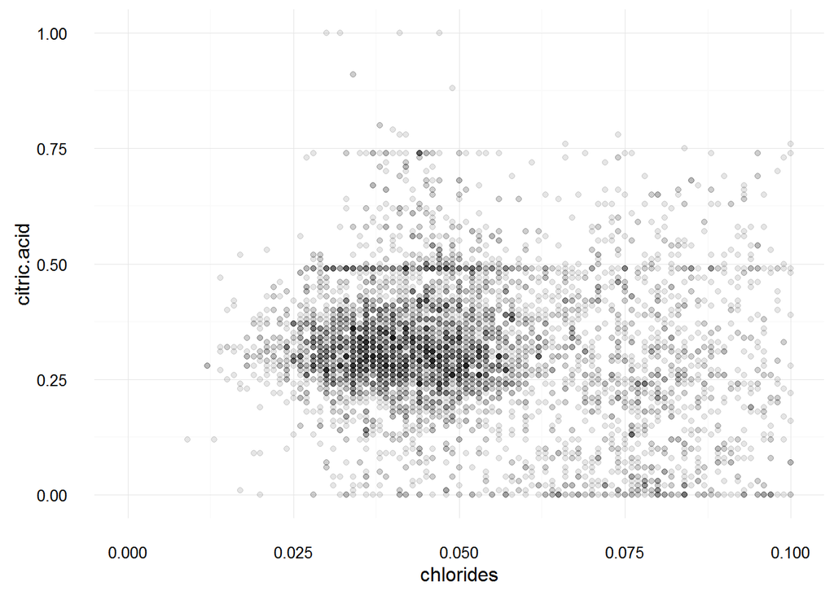

This suggests we should not make the assumption that “taste” variables would be correlated. With a Pearson’s R close to 0, chlorides and citric.acid seem to have little correlation to one another.

## Bivariate Analysis

### Talk about some of the relationships you observed in this part of the investigation. How did the feature(s) of interest vary with other features in the dataset?

In this part of investigation, we created a scatterplot matrix to identify and explore relationships between variables. Using Pearson’s R and scatterplots, we observed the following in the variables of interest:

- Alcohol & Residual.sugar: As residual.sugar level increases, alcohol level decreases. This suggests an inverse relationship between the 2 variables.
- Alcohol & pH: Unlike the intial assumptions, there is no clear relationship between the 2 variables, with a correlation value close to 0.
- Volatile.acidity & Citric.acid: A variable that has a surprisingly high correlation with volatile.acidity is citric.acid. As volatile.acidity level decreases, citric.acid level increases.

### Did you observe any interesting relationships between the other features (not the main feature(s) of interest)?

An interesting relationship I found looking at the scatterplot matrix is citric.acid and chlorides. Although these 2 variables relate to taste, I had decided to focus on variables with higher mean values (residual.sugar & volatile.acidity).

Citric.acid adds freshness and flavor to wines, while chlorides are simply the amount of salt in wine. As such, the assumption was that the 2 variables would be correlated. The scatterplot and R value however showed that there is little to no correlation between the 2 variables.

### What was the strongest relationship you found?

The strongest relationship I found was alcohol & density, with a Pearson’s R of -0.69.

## Multivariate Plots Section

In the previous section, we looked at relationships between two variables and found few pairs with stronger correlations than others. Next, we will add a third variable to better understand the dataset.

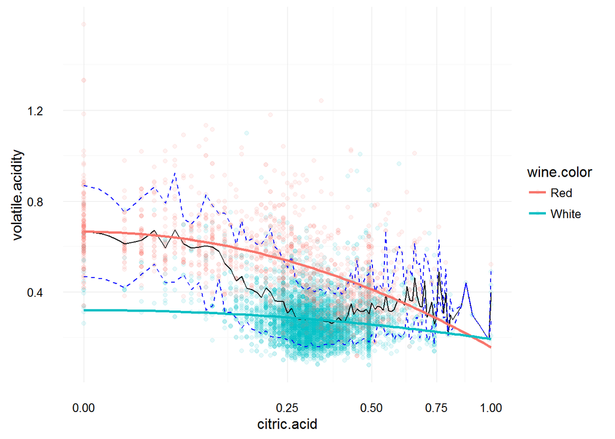

Adding the wine.color variable using color = wine.color, we can see how Red wine overall has higher volatile.acidity level compared to White wine. For both wine types however, the relationship between volatile.acidity and citric.acid remains similar; as citric.acid level increases, volatile.acidity level decreases. This is also the case for top 10 and 90 percentile of the sample.

Earlier, we observed how as residual.sugar level increased, alcohol level decreased steadily. To see whether this is true for both white and red wine, the variable wine.color is added.

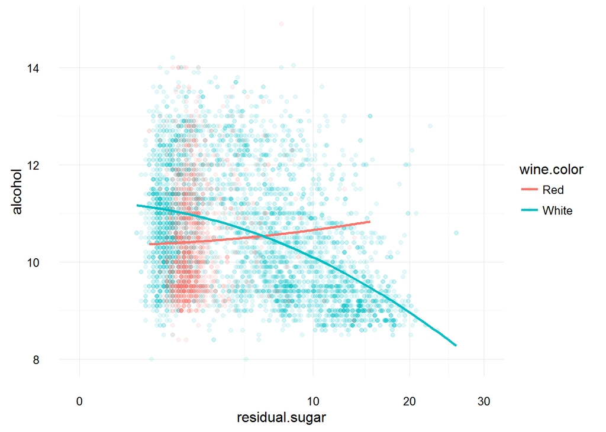

We can observe the following from the above plot:

- White wine has higher level of residual.sugar compared to Red wine.
- White wine shows steadier decrease in alcohol level as residual.sugar level increases.

2 questions that come to mind are how do these variables affect quality ratings? and what role, if any, does alcohol strength play in these relationships? Using cut function to bin alcohol into weak, medium, and strong levels and adding quality.fac as the y-variable, we can take a further look.

```
##
## (7.99,10.3] (10.3,12.6] (12.6,14.9]
##        3295        2846         356
```

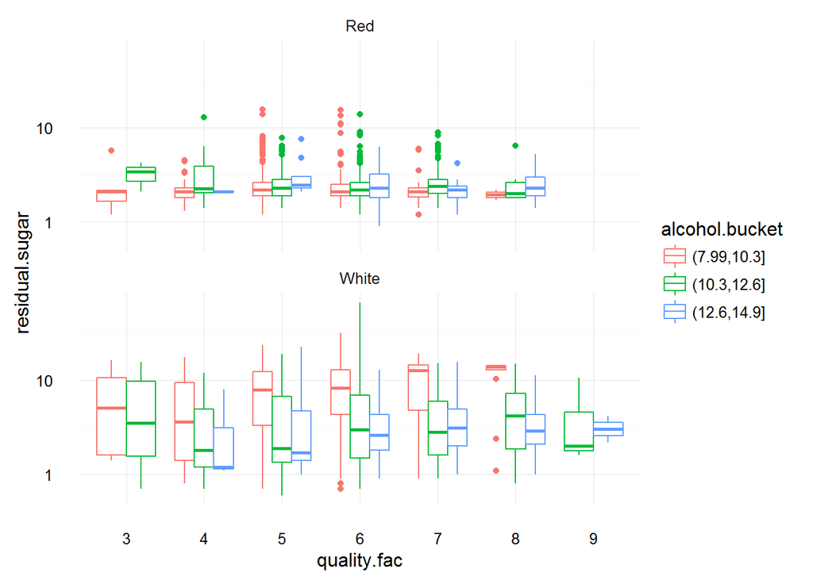

We can observe the following from the above plots:

- White wine samples with higher residual.sugar level have weaker alcohol level.
- Both Red and White wine show similar color patterns, with weaker alcohol level having lower quality ratings and stronger alcohol level having higher ratings.

Earlier we observed that density has a strong correlation with both alcohol and residual.sugar. Using the alcohol buckets created above, let’s take another look.

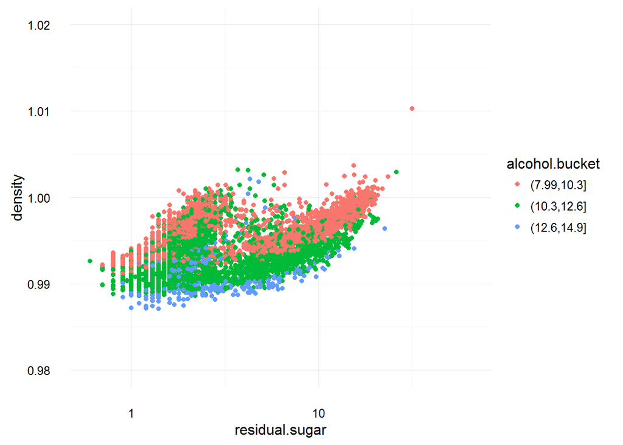

Above plot again shows the following:

- Weaker alcohol level correlates with higher density level.
- Higher residual.sugar level correlates with higher density level.

## Multivariate Analysis

### Talk about some of the relationships you observed in this part of the investigation. Were there features that strengthened each other in terms of looking at your feature(s) of interest?

Adding a 3rd variable, we explored key relationships of interest in this part of the investigation.

- Citric.acid & Volatile.acidity & Wine.color: while Red wine overall has higher volatile.acidity level, both wine types show similar patterns; as citric.acid level increases, volatile.acidity level decreases.
- Alcohol & Residual.sugar & Density: while weaker alcohol level correlates with higher density level, higher residual.sugar level correlates with higher density level.

### Were there any interesting or surprising interactions between features?

- Alcohol & Residual.Sugar & Wine.Color & Quality: While looking at these 4 variables, we found that both Red and White wine were simliar in that weaker alcohol level has lower quality ratings. In addition, we saw again that White wine samples with higher residual.sugar level have weaker alcohol level.

## Final Plots and Summary

### Plot One

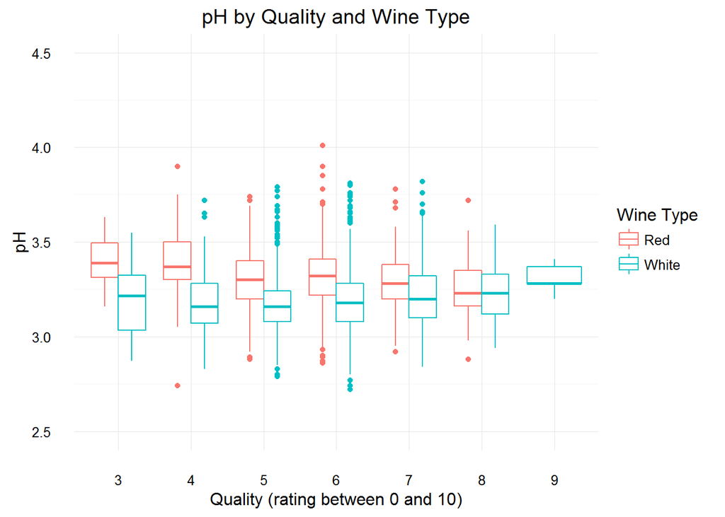

### Description One

Unlike initial assumptions, pH does not seem to vary much across quality ratings. Although White wine generally appears to have lower pH level compared to Red wine, wine sample in general fall between 3 and 4 in the pH scale.

### Plot Two

```
##
##  Pearson's product-moment correlation
##
## data:  citric.acid and volatile.acidity
## t = -32.903, df = 6495, p-value < 2.2e-16
## alternative hypothesis: true correlation is not equal to 0
## 95 percent confidence interval:
##  -0.3986341 -0.3569453
## sample estimates:
##        cor
## -0.3779813
```

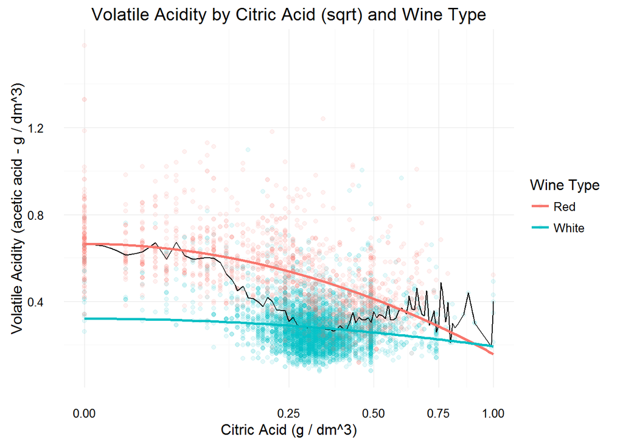

### Description Two

As shown in the downward regression/mean lines and Pearson’s R of -0.38, volatile acidity is negatively correlated with citric acid for both wine types. The graph becomes noisier as citric acid level approaches 1 g/dm^3, but the overall correlation is negative. This is interesting as citric acid known to add ‘freshness’ is inversely correlated to volatile acididty known to cause unpleasant, vinegar taste.

### Plot Three

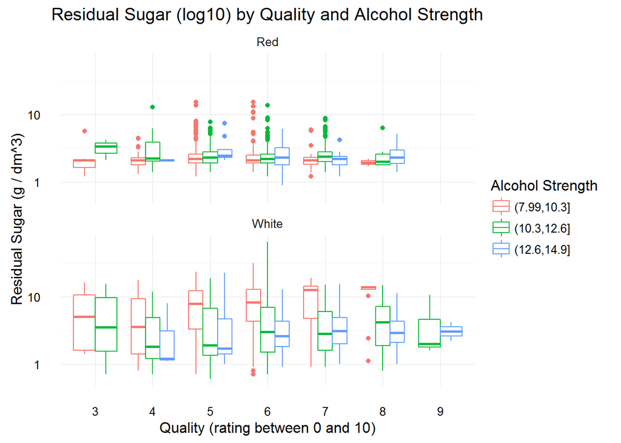

### Description Three

This plot indicates that for both Red and White wine, weaker alcohol level has lower quality ratings. Conversely, stronger alcohol level has higher alcohol ratings. Additionally, White wine samples with more residual.sugar has a weaker alcohol level. These findings suggest that White wine with higher amounts of residual sugar, which correlates with lower alcohol level, would have lower quality ratings.

## Reflection

The wine data set contains information on over 6000 red and white variants of the Portuguese “Vinho Verde” wine. Interested in how taste would affect the ratings, I started by understading the 4 key variables of interest (alcohol, pH, residual sugar, volatile acidity), then looking at their relationships with quality. I explored interesting questions while continuing to make observations on plots.

There was a clear trend between alcohol strength, residual sugar, and quality. Wine samples with higher amounts of residual sugar, which correlates to lower alcohol level had lower quality ratings. It was suprising to find that pH has close to 0 correlation with quality, but it became clear that most wines are between 3-4 on the pH scale. A challenge I had was finding the best way to transform the plots. By using a combination of scale_x_log10 and coord_trans, I was able to show the relationships between variables more clearly. Another challenge was choosing the right type of plot to visualize the variables. Through trial and error, I was able to find the appropriate type for each context.

Some limitations of this model include the source of the data. Given that there are more White wine samples than Red, we are not able to clearly draw a comparison between the two. To investigate this dataset further, I would create a linear model to predict the quality ratings and to determine to what extent the model is accurate. Having an equal number of Red and White samples would be better to make predictions of quality ratings.

#### Citation

P. Cortez, A. Cerdeira, F. Almeida, T. Matos and J. Reis. Modeling wine preferences by data mining from physicochemical properties. In Decision Support Systems, Elsevier, 47(4):547-553, 2009.